# Compare CFU and FungaLight for log dilution of H2O2

Hanxi Tang, Bin He

2024-03-22 (updated 2025-02-27 10:27:42.414795)

```r
require(tidyverse)
require(flowCore)
require(flowClust)
require(openCyto)
require(ggcyto)
require(cowplot)
#require(ggrdiges)
```

```r
old <- theme_set(theme_minimal(base_size = 14) + panel_border(color = "gray20"))
```

# Background & Goal

Having optimized the FungaLight assay conditions, we would like to compare its estimates to those by CFU and PI alone, two commonly used methods in the literature.

The experiments for *C. glabrata* were conducted on 2024.02.14-17. Post-treatment cells were stained with PI or PI+SYTO9, and run through flow cytometry. The same sample was also plated for CFU.

A similar experiment was done for *S. cerevisiae* on 2024.02.25-28.

# Import data

> FCS files are stored in rdss/Users/Hanxi/flow cytometry under the above dates. They are copied to this repository under the same names.

*note*: samples are labeled by the H2O2 doses they were treated with. an exception is “5C”, which refers to samples taken prior to the treatment and stored in the fridge at 5 Celsius until treated samples are ready for flow cytometer. this was done as a control experiment. ask Hanxi about the specific rationale.

```r
# use relative path to make it easier for collaboration
data.path = "../input/20240214-17 Log H2O2 correlation Cg/"
dat0 <- read.flowSet(path = data.path, pattern = "*.fcs",
                     transformation = FALSE,  # the original values are already linearized.
                     emptyValue = FALSE,  alter.names = TRUE,   # change parameter names to R format
                     column.pattern = ".H|FSC|SSC") # only load the height variables for the fluorescent parameters
```

Simplify the sample names

```r
oriNames <- sampleNames(dat0)
tmp <- str_split(oriNames, pattern = "[ _]+", simplify = TRUE)[,c(1, 6, 7)]
colnames(tmp) <- c("Date", "Treatment", "Dye")
#treatment.levels <- c("mock", "5C", "10", "100", "1000")
sample <- data.frame(tmp) %>%
  mutate(
    Dye = ifelse(Dye == "p.fcs", "PI", ifelse(Dye == "b.fcs", "Both", Dye)),
    Treatment = fct_inorder(Treatment),
    name = paste(Date, paste0(Treatment,
                              ifelse(Treatment == "5C", "", "mM")),
                 Dye, sep = "_")
  )
rownames(sample) <- oriNames
dat <- dat0 # make a copy
pData(dat) <- sample
write_tsv(pData(dat), file = "../input/20240214-log-h2o2-cg-sample.tsv")
```

# Gatting strategies

## Load all gates from specification file

```r
source("../script/20250206-FGL-flow-gate-specification.R")
# below were the content initially used to populate the specification file above
## outlier gate
#outlier.gate <- rectangleGate(filterId = "-outlier", "FSC.H" = c(1.2e5, 1e6), "SSC.H" = c(1e2, 1e6))
## single cell gate
#polygon <- matrix(c(1e5, 1e5, 1e6, 1e6,
#                    60, 105, 135,60), ncol = 2)
#colnames(polygon) <- c("FSC.H", "FSC.W")
#singlet.gate <- polygonGate(filterId = "singlet", .gate = polygon)
## live cell gate
#polygon <- matrix(c(0, 5*10^3, 5*10^3, 0, # BL1.H, green
#                    10^2.2, 10^2.2, 0, 0),# BL3.H, red
#                  ncol = 2)
#colnames(polygon) <- c("BL1.H", "BL3.H")
#live.gate <- polygonGate(filterId = "live", .gate = polygon)
## intermediate gate
#polygon <- matrix(c(10^3, 10^5.5, 10^5.5,   # BL1.H, green
#                    10^2.2, 10^2.2, 10^4.5),# BL3.H, red
#                  ncol = 2)
#colnames(polygon) <- c("BL1.H", "BL3.H")
#inter.gate <- polygonGate(filterId = "inter", .gate = polygon)
```

## Gating for singlets

> The following gaphing steps are used to gate singlets by FSC and SSC values. Only singlets are included in analysis. Gate for outlier

[output not shown]

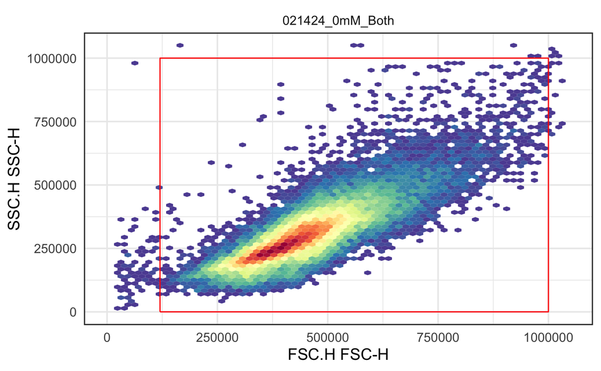

```r
#outlier.gate <- rectangleGate(filterId = "-outlier", "FSC.H" = c(1.2e5, 1e6), "SSC.H" = c(1e2, 1e6))
ggcyto(dat[1], aes(x = FSC.H, y = SSC.H), subset = "root") +
  geom_hex(bins = 64) + geom_gate(outlier.gate) + facet_wrap(~name, ncol = 2) + ggcyto_par_set(limits = "instrument")
```

Add gate to GS

```r
gs <- GatingSet(dat) # create a GatingSet
# rename the samples
sampleNames(gs) <- pData(gs)$name
# repair the Date column in pData
pData(gs)$Date = paste0("0", pData(gs)$Date)
# add the outlier gate
gs_pop_add(gs, outlier.gate, parent = "root")
```

```
[1] 2
```

```r
recompute(gs)
```

```
done!
```

> Gate for singlets

[output not shown]

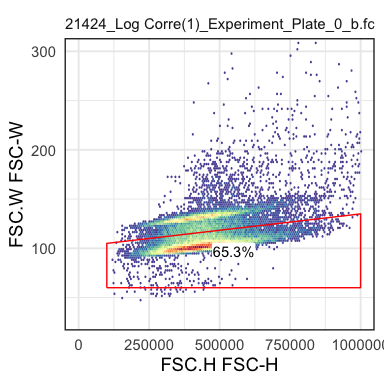

```r
scPars <- ggcyto_par_set(limits = list(x = c(0,1e6), y = c(30,300)))
ex <- Subset(dat[[1]], outlier.gate)
#polygon <- matrix(c(1e5, 1e5, 1e6, 1e6,
#                    60, 105, 135,60), ncol = 2)
#colnames(polygon) <- c("FSC.H", "FSC.W")
#singlet.gate <- polygonGate(filterId = "singlet", .gate = polygon)
ggcyto(ex, aes(x = FSC.H, y = FSC.W)) + geom_hex(bins = 128) + geom_gate(singlet.gate) + geom_stats() + scPars
```

Add this gate to the gatingSet

```r
gs_pop_add(gs, singlet.gate, parent = "-outlier", name = "singlet")
```

```
[1] 3
```

```r
recompute(gs)
```

```
done!
```

## Gate for live cells

This is the live population with red fluorescence below 10^2.2

> **Main takeaway**
> 1. From 10mM to 1M treated samples, %live decreases and the change is much more obvious in the dual stain (PI first or simultaneous) than PI alone
> 2. The mock treated sample has a visible high red high green (not as high and prominent as the 100 mM treated) than 10 mM treated. It doesn’t follow the trend above.

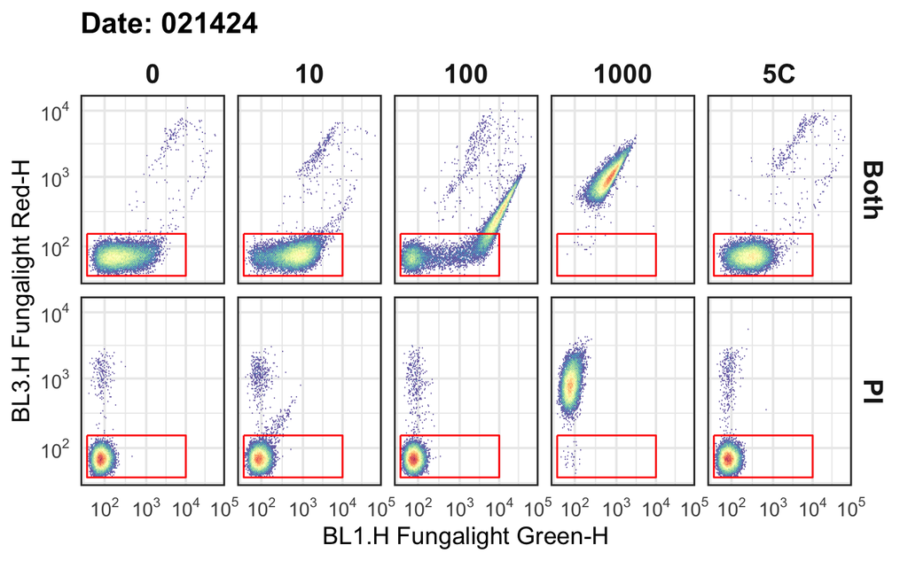

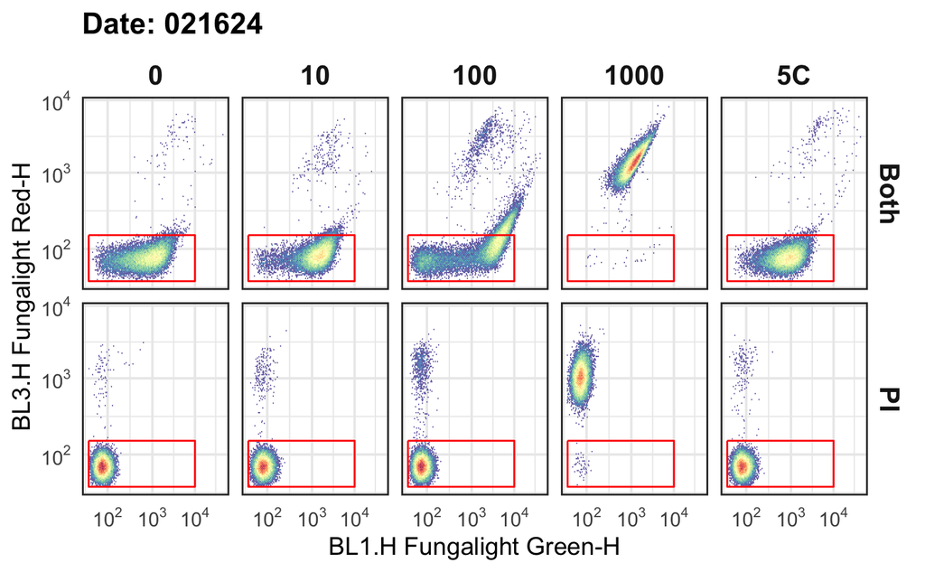

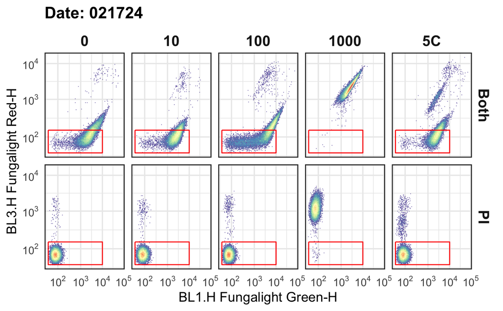

```r
scPars <- ggcyto_par_set(limits = list(x = c(0,10^5.5), y = c(0,10^5.5)))
#polygon <- matrix(c(0, 5*10^3, 5*10^3, 0, # BL1.H, green
#                    10^2.2, 10^2.2, 0, 0),# BL3.H, red
#                  ncol = 2)
#colnames(polygon) <- c("BL1.H", "BL3.H")
#live.gate <- polygonGate(filterId = "live", .gate = polygon)
p.axis <- list(
  scale_x_logicle(breaks = 10^c(2,3,4,5)),
  scale_y_logicle(breaks = 10^c(2,3,4,5)),
  theme(
    strip.text = element_text(size = rel(1.1), face = 2)
  )
)
for(date in c("021424", "021624", "021724")){
  p <- ggcyto(gs[pData(gs)$Date == date], aes(x = BL1.H, y = BL3.H), subset = "singlet") +
    geom_hex(bins = 128) +
    geom_gate(live.gate) +
    geom_stats(location = "data", adjust = c(0.005, 5), digits = 1) +
    labs(title = paste0("Date: ", date)) +
    facet_grid(Dye ~ Treatment) +# scPars +
    p.axis
  print(p)
}
```

Add this gate to the gatingSet

```r
gs_pop_add(gs, live.gate, parent = "singlet", name = "live")
```

```
[1] 4
```

```r
recompute(gs)
```

```
done!
```

## Gate for the intermediate population with high SYTO9

This is the intermediate population with high Red and Green. We hypothesize that they represent oxidatively damaged cells with partially compromised plasma membranes, resulting in more SYTO9 accumulation but not a significant increase in PI.

[output not shown]

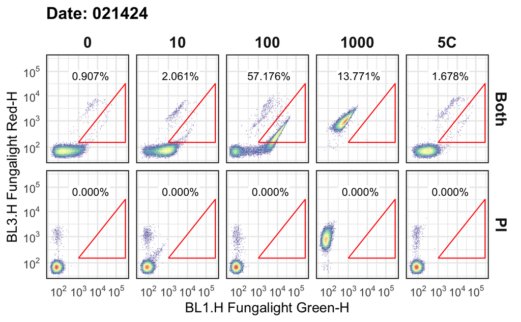

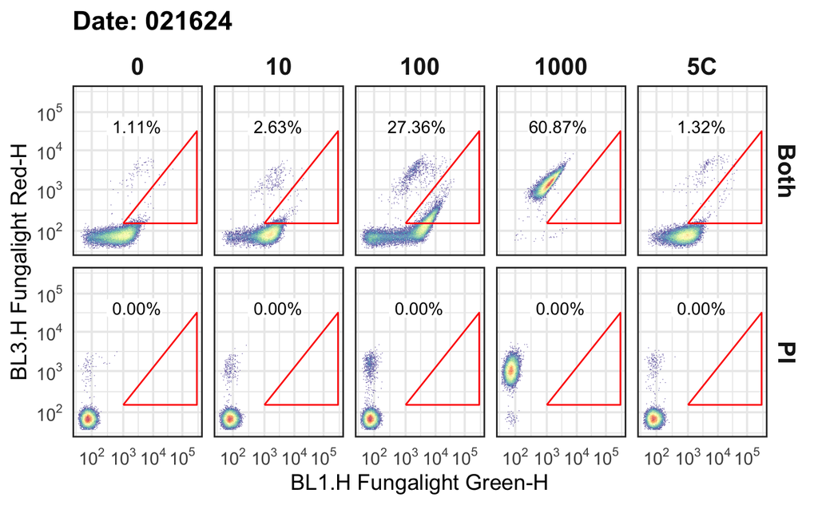

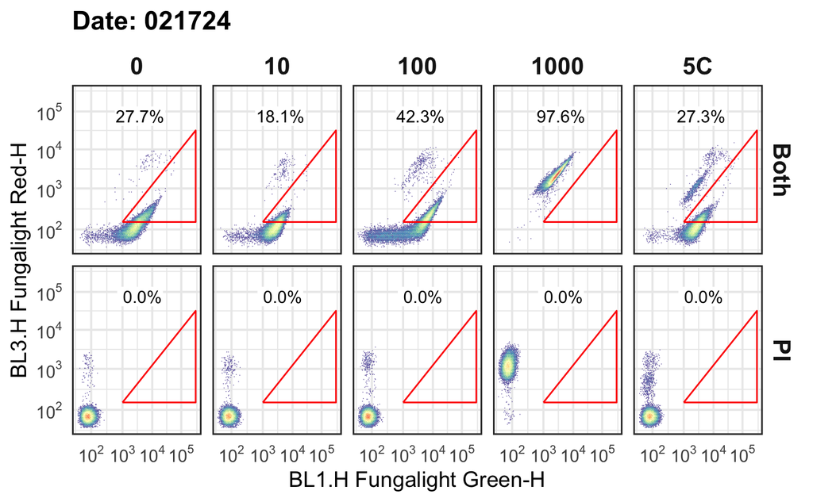

```r
#polygon <- matrix(c(10^5, 1*10^3, 10^5,
#                    10^2.2, 10^2.2, 10^4), ncol = 2)
#polygon <- matrix(c(10^3, 10^5.5, 10^5.5,   # BL1.H, green
#                    10^2.2, 10^2.2, 10^4.5),# BL3.H, red
#                  ncol = 2)
#colnames(polygon) <- c("BL1.H", "BL3.H")
#inter.gate <- polygonGate(filterId = "inter", .gate = polygon)
for(date in c("021424", "021624", "021724")){
  p <- ggcyto(gs[pData(gs)$Date == date], aes(x = BL1.H, y = BL3.H),
              subset = "singlet") +
    geom_hex(bins = 128) +
    geom_gate(inter.gate) +
    geom_stats(location = "data",  adjust = c(0.05, 5), digits = 3) +
    labs(title = paste0("Date: ", date)) +
    facet_grid(Dye ~ Treatment) + scPars +
    p.axis
  print(p)
}
```

```r
gs_pop_add(gs, inter.gate, parent = "singlet", name = "intermediate")
```

```
[1] 5
```

```r
recompute(gs)
```

```
done!
```

## Example plot of the gating strategy

It’s recommended by many journals to show an example of the gating strategy. This is especially important and useful in this case. We will separately illustrate the gating for the PI-alone and FungaLight

```r
scPars <- ggcyto_par_set(limits = list(x = c(0,10^5.5), y = c(0,10^5)))
# sample #6 is 100 mM treated, PI stained cell
p.exp_PI <- ggcyto(gs[[26]], aes(x = BL1.H, y = BL3.H), subset = "singlet") +
  geom_hex(bins = 64) +
  geom_gate(live.gate, colour = "gray20") +
  labs(title = NULL, x = NULL, y = NULL) +
  facet_wrap(~Dye) +
  p.axis + scPars
```

[output not shown]

```r
# sample #5 is 100 mM treated, both SYTO9+PI stained cell
p.exp_FGL <- ggcyto(gs[[25]], aes(x = BL1.H, y = BL3.H), subset = "singlet") +
  geom_hex(bins = 64) +
  geom_gate(live.gate, colour = "gray20") +
  geom_gate(inter.gate, colour = "steelblue3") +
  labs(title = NULL, x = NULL, y = NULL) +
  facet_wrap(~Dye, labeller = labeller(Dye = c("Both" = "FungaLight"))) +
  p.axis + scPars
```

[output not shown]

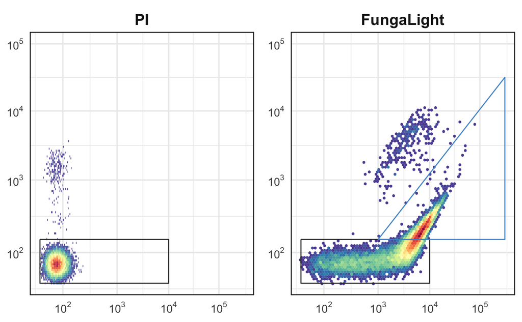

```r
plot_grid(as.ggplot(p.exp_PI), as.ggplot(p.exp_FGL))

p.exp <- plot_grid(
  as.ggplot(p.exp_PI) +
    theme(strip.text = element_text(size = rel(0.9), face = 1)),
  as.ggplot(p.exp_FGL) +
    theme(strip.text = element_text(size = rel(0.9), face = 1),
          axis.text.y = element_blank(),),
  ncol = 2, rel_widths = c(1.15, 1)
)
ggsave("../output/20250115-gating-strategy-example.png", p.exp,
       height = 2.2, width = 3.4)
```

## Explore cell size difference in hydrogen peroxide treated cells

This is based on Jinye’s suggestion: > I am wondering is whether the cell size and granularity would affect the staining in different ways among species. Thus, I think it makes sense to plot the FL on FSC or SSC and perform a linear regression analysis for each species, if there is no significant difference, we can say the cell property of different species does not affect the staining in different ways. This is a simplified or adapted idea from PMID: 21952134.

Let’s plot the distribution of FSC.H as a proxy for cell size

```r
mult_format <- function() {
     function(x) format(x/10000,digits = 2)
}
```

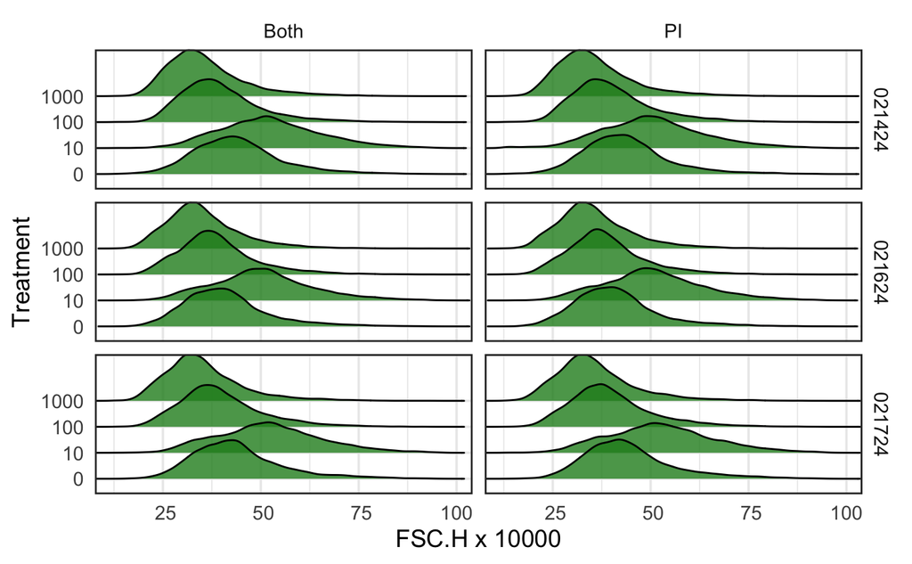

```r
subset <- with(pData(gs), Treatment != "5C")
p1 <- ggcyto(gs[subset], aes(x = FSC.H), subset = "singlet") +
  ggridges::geom_density_ridges(aes(y = Treatment),
                                fill = "forestgreen", alpha = 0.8) +
  scale_x_continuous(labels = mult_format(), name = "FSC.H x 10000") +
  facet_grid(Date ~ Dye) + labs(title = NULL)
p1
ggsave("../output/20250226-log-h2o2-cell-size-distribution-compare.png",
       width = 4, height = 4)
```

# Extract gated stats and MFI

% of events in each of the three gates

```r
# we are only interested in the populations after singlet gating
nodes <- c("singlet", "intermediate", "live")
# get the event count
gated_cnt <- gs_pop_get_stats(gs, nodes, type = "count")
# get the MFI for each parameter in each population of interest
gated_mfi <- gs_pop_get_stats(gs, nodes, type = pop.MFI) %>%
  select(sample, pop, starts_with("FungaLight"))
```

Combine the data and meta data

```r
gated_stats <- full_join(gated_cnt, gated_mfi, by = c("sample", "pop")) %>%
  right_join(pData(gs), by = c("sample" = "name")) %>%
  relocate(Date, Treatment, Dye, .after = sample) %>%
  relocate(sample, .after = last_col())
write_tsv(gated_stats, file = "../output/20240124-log-h2o2-Cg-gated-stats.tsv")

# we don't need the MFI for the latter analysis. add meta data to gated_cnt
gated_freq <- left_join(sample, gated_cnt, by = c("name" = "sample")) %>%
  select(-name) %>%
  group_by(Date, Treatment, Dye) %>%
  mutate(perc = count / count[pop == "singlet"], .after = count)
```

```
#gated_stats <- gs_pop_get_stats(gs, type = "count") %>%
#  as_tibble() %>%
#  mutate(pop = gsub(".*/", "", pop), pop = gsub("-outlier", "cells", pop)) %>%
#  pivot_wider(names_from = pop, names_prefix = "n_", values_from = count) %>%
#  mutate(
#    #p_singlet = n_singlet / n_cells,
#    p_live = n_live / n_singlet,
#    p_intermediate = n_intermediate / n_singlet,
#    p_dead = 1 - p_live - p_intermediate
#  )
#write_tsv(gated_data, file = "../Input/20240124-fig-2-Dye-Order-gated-ht.tsv")
#print(gated_data)
```

```
final <- select(pData(dat), sample = name, everything()) %>%
  left_join(select(gated_stats, -starts_with("n_")),  by = "sample") %>%
  left_join(popMFI, by = "sample")

write_tsv(final, file = "../output/12.03-gated-output-20240214.tsv")
print(final %>% select(-sample))
```

# Compare with CFU

## Read CFU data

These are averaged CFU provided by Hanxi. The raw counts data will be provided by her separately.

```r
cfu <- read_tsv("../input/20240219-log-h2o2-Cg-CFU-HT.tsv") %>%
  mutate(Method = "CFU", .after = Treatment) %>%
  mutate(Treatment = fct_recode(Treatment, `0` = "mock")) %>%
  rename(p_live = CFU)
```

Here are the raw cfu data

```r
cfu_raw <- read_tsv("../input/20240214-0405-h2o2-Cg-CFU-raw.tsv",
                    col_types = "cccccciiii", comment = "#")
cfu_calc <- cfu_raw %>%
  select(Date, Treatment = H2O2_mM, Group, Dilution, Raw_count = Total) %>%
  mutate(Date = ymd(Date),
         Treatment = fct_inseq(Treatment),
         CFU = Dilution * Raw_count) %>%
  # group by Date to calculate the ratio of MO to MM
  group_by(Date) %>%
  mutate(p_live = CFU / CFU[Group == "MM"]) %>%
  # we only need the log dilution series
  dplyr::filter(Date < ymd("20240301"))

# export the data for paper
write_tsv(cfu_calc, file = "../output/20250226-log-h2o2-cfu-estimate.tsv")
```

## Calculate survival from PI alone or FungaLight

For both PI alone and FungaLight, we will calculate the percent live events. For FungaLight specifically, we will also record the percent intermediate events and will investigate its utility

```r
dye_based <- gated_freq %>%
  # record the total number of events as the count of singlets
  group_by(Date, Treatment, Dye) %>%
  mutate(total_event_count = count[pop == "singlet"]) %>%
  # now we don't need the singlet population and the count variable
  select(-count) %>%
  dplyr::filter(pop != "singlet") %>%
  #ungroup() %>%
  # we will pivot this data frame to a wider format, making
  # two new variables out of the percentage variable
  pivot_wider(names_from = pop, values_from = perc, names_prefix = "p_") %>%
  mutate(p_dead = 1 - p_live - p_intermediate) %>%
  relocate(p_live, .after = total_event_count)

# export the data for paper
write_tsv(dye_based, file = "../output/20250226-log-h2o2-fgl-estimate.tsv")
```

```
PI <- final %>%
  dplyr::filter(Dye == "PI") %>%
  select(Date, Treatment, Method = Dye, Score = p_live)

FGL <- final %>%
  dplyr::filter(Dye == "Both") %>%
  mutate(
    wFGL = p_live * 2/log(BL1_live, 10)
  ) %>%
  select(Date, Treatment, wFGL, FGL = p_live) %>%
  pivot_longer(cols = c(wFGL, FGL), names_to = "Method", values_to = "Score")


all <- bind_rows(
  PI, FGL,
  mutate(cfu, Method = "CFU") %>% rename(Score = CFU)
)
```

Combine the dye based results with cfu

```r
cfu_dye <- bind_rows(cfu,
  select(dye_based, Date, Treatment, Method = Dye, starts_with("p"))) %>%
  mutate(
    Method = factor(Method, levels = c("CFU", "PI", "Both"),
                    labels = c("CFU", "PI", "FungaLight")),
    Treatment = fct_inorder(Treatment)
  )
```

## Plotting the results

Compare the three methods

```r
h2o2.levels <- c("0" = "0", "10" = "10", "100" = "100", "1000" = "1K")
p <- cfu_dye %>%
  dplyr::filter(Treatment != "5C") %>%
  ggplot(aes(x = Treatment, y = p_live, group = Method)) +
  geom_bar(stat = "summary", fun = "mean", fill = "gray70", width = 0.7) +
  geom_point(aes(shape = Date), position = position_jitter(0.2),
             size = 1.5) +
  scale_shape_manual(values = 4:6, guide = "none") +
  scale_y_continuous(labels = scales::percent,
                     limits = c(NA, 1.1), breaks = seq(0,1,0.5)) +
  scale_x_discrete(labels = h2o2.levels) +
  #coord_flip() +
  labs(x = bquote(H[2]*O[2]~(mM)), y = "% Live") +
  facet_wrap(~Method, nrow = 1) +
  theme(strip.background = element_blank(),
        strip.text = element_text(size = rel(0.9), face = 1),
        axis.text.x = element_text(size = rel(0.9), angle = 90, vjust = .5),
        axis.text.y = element_text(size = rel(0.9)),
        axis.title = element_text(size = rel(0.9)),
        panel.spacing = unit(1, "lines"))
p
ggsave("../output/20250116-perc-live-compare-three-methods.png",
       width = 4, height = 2.5)
```

[output not shown]

Check the percent of events in the “Intermediate” gate.

```r
p.dye <- dye_based %>%
  dplyr::filter(Treatment != "5C", Dye == "Both") %>%
  ggplot(aes(x = Treatment, y = p_live)) +
  geom_bar(stat = "summary", fun = "mean", fill = "gray70", width = 0.8) +
  geom_point(aes(shape = as.character(Date)),
             position = position_jitter(0.1),
             size = 1.5) +
  # overlay the p_intermediate points
  stat_summary(aes(y = p_intermediate), geom = "point", shape = 19, size = 3,
               fun = "mean", color = "steelblue3") +
  stat_summary(aes(y = p_intermediate, group = NA), geom = "line",
               fun = "mean", color = "steelblue") +
  geom_point(aes(y = p_intermediate, shape = as.character(Date)),
             position = position_jitter(0.1),
             color = "steelblue", size = 1.5, stroke = 1.2) +
  scale_shape_manual(values = 4:6, guide = "none") +
  scale_y_continuous(labels = scales::percent, breaks = seq(0,1,0.25)) +
  labs(title = "CFU", x = bquote(H[2]*O[2]~(mM)), y = "% Live") +
  theme(strip.text = element_text(size = rel(1.2), face = 2),
        strip.background = element_blank(),
        plot.title = element_text(hjust = 0.5))

p.dye
```

[output not shown]

```r
p.dye <- ungroup(dye_based) %>%
  dplyr::filter(Treatment != "5C", Dye == "Both") %>%
  select(Date, Treatment, p_live, p_intermediate) %>%
  pivot_longer(cols = c(p_live, p_intermediate),
               names_to = "par", values_to = "perc") %>%
  mutate(par = factor(par, levels = c("p_live", "p_intermediate"),
                      labels = c("% live", "% intermediate"))) %>%
  ggplot(aes(x = Treatment, y = perc, group = par)) +
  geom_bar(aes(fill = par), position = position_dodge(.9),
    stat = "summary", fun = "mean", width = 0.8) +
  geom_point(aes(shape = as.character(Date), color = par),
             position = position_jitterdodge(jitter.width = 0.1,
                                             dodge.width = 0.9),
             size = 1.5, stroke = 1.2) +
  scale_fill_manual(NULL, values = c("gray70", "lightblue3")) +
  scale_color_manual(NULL, values = c("black", "steelblue")) +
  scale_shape_manual(values = 4:6, guide = "none") +
  scale_y_continuous(labels = scales::percent, breaks = seq(0,1,0.25)) +
  labs(title = "CFU", x = bquote(H[2]*O[2]~(mM)), y = NULL) +
  theme(strip.text = element_text(size = rel(1.2), face = 2),
        strip.background = element_blank(),
        plot.title = element_text(hjust = 0.5),
        legend.position = "inside",
        legend.position.inside = c(0.8, 0.9))

p.dye
```

[output not shown]

## Statistical tests

We use ANOVA and posthoc test to test for significant differences between the conditions

```r
#tmp <- dplyr::filter(cfu_dye, Treatment != "5C", Method == "FungaLight") %>%
#  mutate(Treatment = fct_inseq(Treatment))
#lm <- aov(p_live ~ Treatment, data = tmp)
#TukeyHSD(lm)

cfu_dye %>%
  dplyr::filter(Treatment != "5C") %>%
  mutate(Treatment = fct_inseq(Treatment)) %>%
  select(Treatment, Method, p_live) %>%
  nest(data = c(Treatment, p_live)) %>%
  mutate(
    fit = map(data, \(df) aov(p_live ~ Treatment, data = df)),
    posthoc = map(fit, TukeyHSD),
    tidied = map(posthoc, tidy)
  ) %>%
  unnest(tidied) %>%
  select(Method, contrast, diff = estimate, lwr = conf.low, upr = conf.high,
         Padj = adj.p.value)
```

[output not shown]

Below are hanxi’s plotting code